# Analisis Exploratorio de Datos ENCSPA-2019- Proyecto Final Estadistica I

David Zapata - Marian Becerra

2024-12-10

# Consumo de Sustancias Psicoactivas en Santander

[figure not shown]

## Introducción

El ministerio de Justicia y Derecho de Colombia observo el consumo de sustancias psicoactivas como un problema crítico, no solo por el aumento que se evidencia día a día, sino por las características que lo hacen un asunto complejo en el tema social y de salud pública.

Se reconoce que, aunque en algunos casos el dejar el consumo es un proceso sencillo, en otros el consumo de sustancias se vuelve persistente y logra afectar la salud, las relaciones sociales, familiares, laborales y/o académicas; la diferencia entre estos puede radicar en varios aspectos como lo son la sustancia, la persona y su contexto social.

En conjunto al ministerio de Justicia, el Departamento Administrativo Nacional de Estadística (DANE) en el año 2019 realizo la *Encuesta Nacional de Consumo de Sustancias Psicoactivas en la Población General (ENCSPA-2019)* esto con el fin de conocer la situación del país en ese momento, para así, diseñar acciones de política pública, planes, programas y proyectos de forma nacional, departamental y municipal.

Conociendo esto, se logra plantear la pregunta ¿qué características predominan en los consumidores de sustancias psicoactivas en Santander?, para la cual se encontrará respuesta a lo largo de este análisis. .

## Metodología

Mediante la recopilación de los datos que el DANE tiene con acceso público respecto a *Encuesta Nacional de Consumo de Sustancias Psicoactivas en la Población General* se lleva a cabo una investigación documental, donde se recopilo la información necesaria.

En su sitio web se puede acceder de forma separada los datos correspondientes a las personas y las características generales de quienes consumen cada una de las sustancias caracterizadas, los cuales fueron tratados de la siguiente forma:

**1. Recopilación y Elección de Datos**

1.1. Descargar los archivos .zip ya que estos almacenaban los .csv que contenidan los datos sin filtro alguno contabamos con mucha información que no tenia ningun tipo de relevancia para la pregunta de investigación planteada.

1.2. Revisión de los items y diccionario de datos de las encuestas realizadas que nos permitieran observar ciertos comportamientos en los datos que además de ellos fueran persistentes en las sustancias y las personas seleccionadas.

1.3. Se eligen como variables de estudio características específicas que se presentan en todas las personas a la que se le realizó la encuesta, y se acotan las sustancias psicoactivas a las cuales se les prestará atención.

**2. Selección, fusión y constraste de datos.**

2.1. Se fija como sustancias a estudiar el bazuco, la cocaína, el éxtasis, la heroína y la marihuana, donde se observa cuando se dio la primera vez y si dentro de los últimos 12 meses la persona había consumido el psicoactivo.

2.2. Del mismo modo, se seleccionan como ítems necesarios a estudiar en las características de las personas como lo son aporte al hogar, en que ocupan su tiempo, estado de salud, si pertenece a alguna minoría, el nivel educativo máximo alcanzado, su orientación sexual, identidad de género, el sexo de nacimiento y la edad.

2.3. Se toman los respectivos *.csv* de cada sustancia de donde se extrae la columna “Directorio” la cual contiene una clave por persona, cuya unicidad permite la fusión desde los archivos donde se encuentran las características de las personas que consumen dicha sustancia, al igual que el código de departamento desde la columna “Depmuni”, el cual permite más adelante el clasificado por departamento de los datos fusionados.

**3. Filtrado y Análisis de Datos**

3.1. Una vez se tiene los archivos con la información necesaria, se inicia un proceso de depuración en donde se dejan únicamente los datos con los cuales se va a trabajar, esto tiene el fin de que el manejo de los mismos sea más sencillo en términos computacionales.Para ello se hizo uso de librerias como read y dplyr.

3.2. Como primer ítem se hace el análisis del consumo por departamento de cada una de las sustancias evaluadas, cuyo resultado se verá en el *mapa de calor* con respecto al consumo de sustancias psicoactivas en el país.

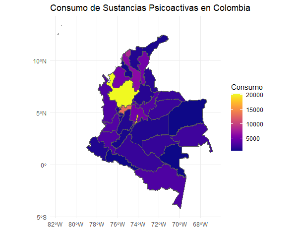

3.3. Se eligen los 4 departamentos donde se observan los valores de mayor consumo en total de sustancias psicoactivas, los cuales son Antioquia, Santander y Valle del Cauca, adicional a ello la ciudad de Bogotá D.C, en donde se realiza el análisis de cada una de las variables nombradas anteriormente por cada una de las sustancias psicoactivas, cuyos resultados darán pie a la discusión y respuesta de la pregunta de investigación.

## Análisis de consumo basado en Santander

Luego de realizar todo el proceso anterior con los datos de Santander, filtrando los datos según la ocupación, el estado de salud, si pertenece a alguna minoría, el nivel educativo máximo alcanzado, su orientación sexual, identidad de género, el sexo de nacimiento y la edad, separando cada una por la sustancia que consume la persona, antes se realizan los *mapas de calor* del consumo de por cada sustancia en el departamento analizando cada uno de sus municipios:

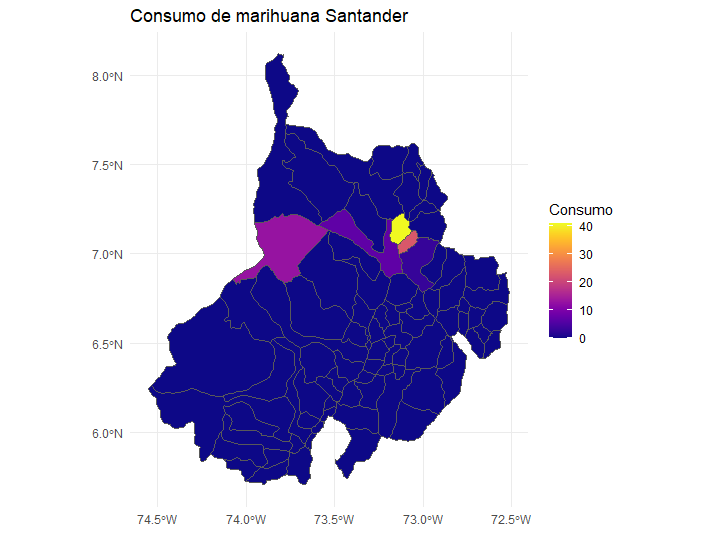

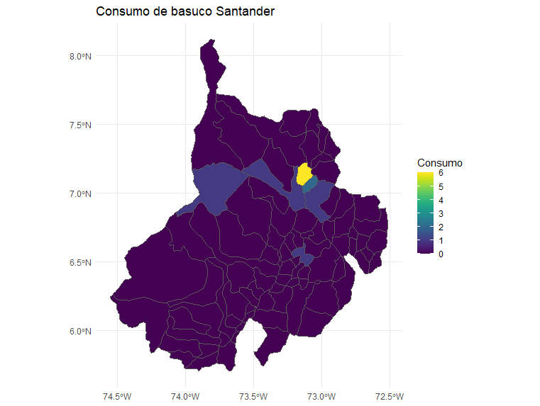

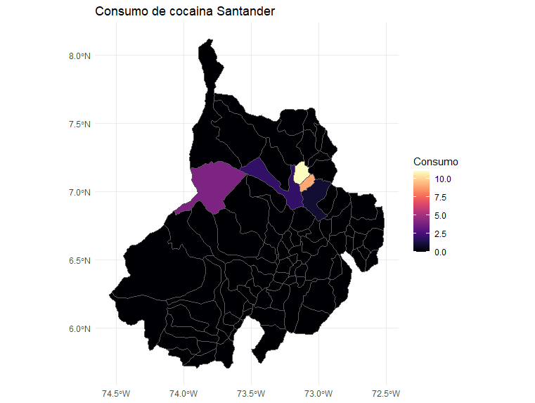

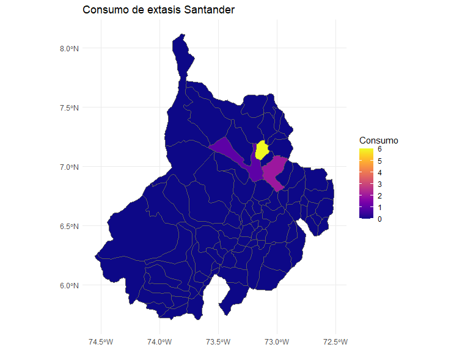

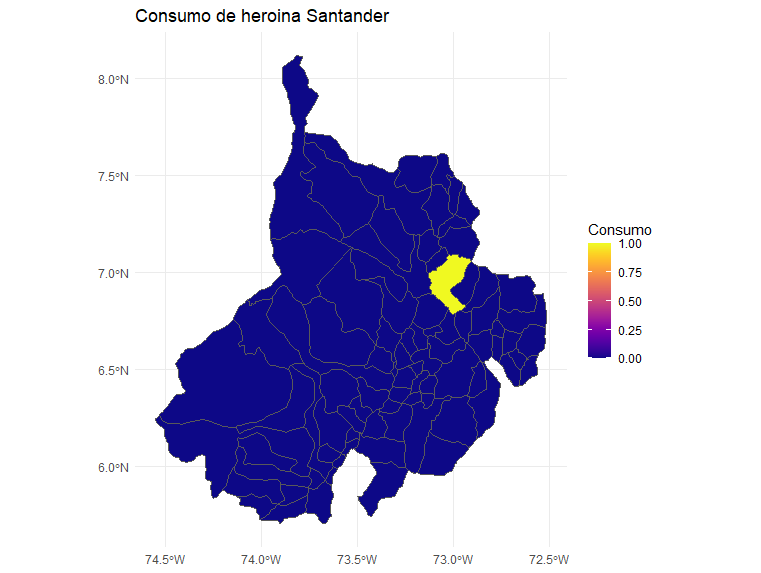

El formato anterior se uso para cada uno de los mapas generados por sustancia psicoactiva a estudiar.

De este mapeo podemos observar que la mayoria de consumidores de sustancias psicoactivas en Santander se encuentran en el area metropolitana que esta conformada por, Floridablanca, Bucaramanga, Piedecuesta y Girón.

## Análisis de variables

Para nuestro informe se sacaron gráficas basandonos en las siguientes variables:

**1. Consumo de sustancias por primera vez**

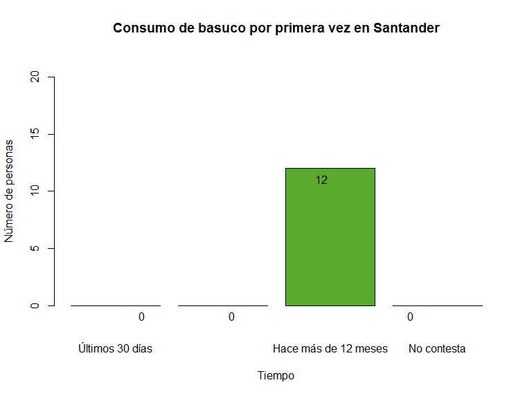

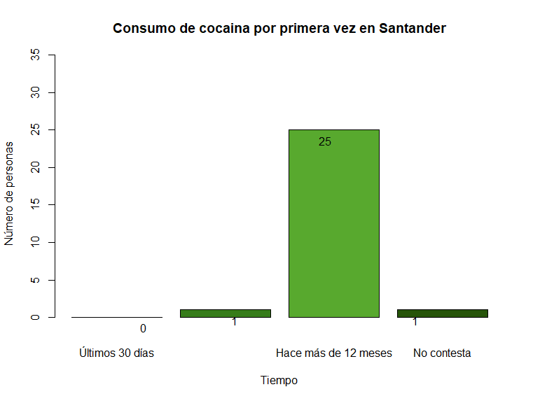

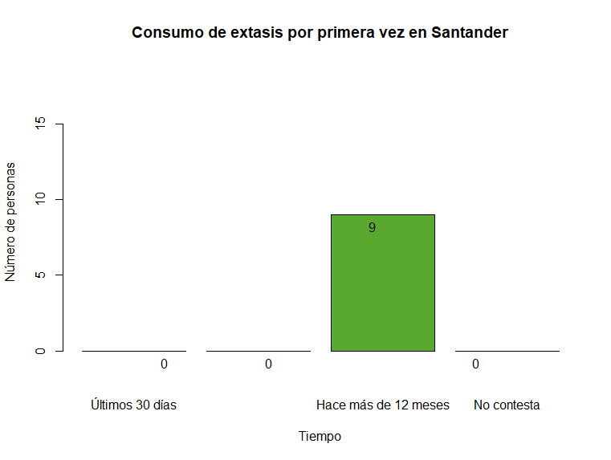

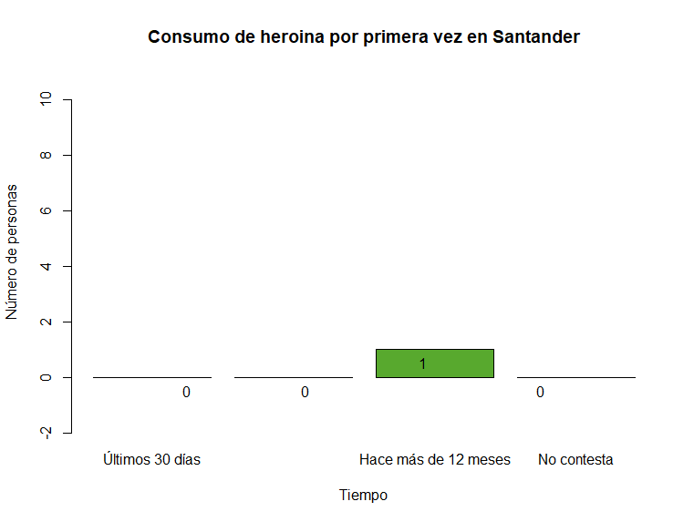

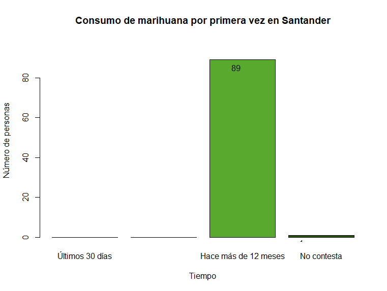

**2. Consumo y trabajo:**

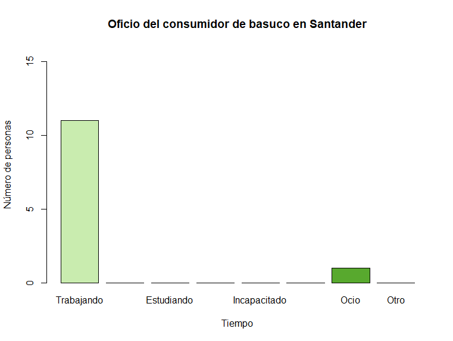

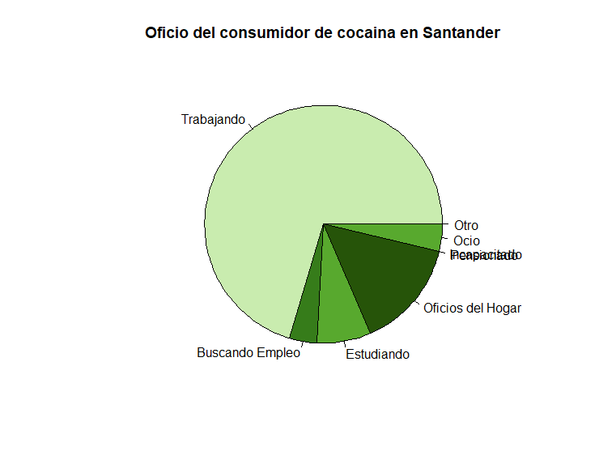

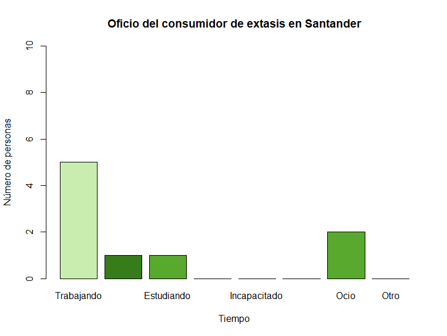

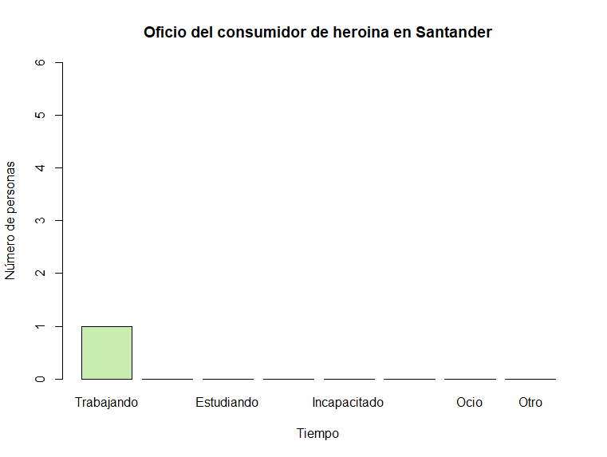

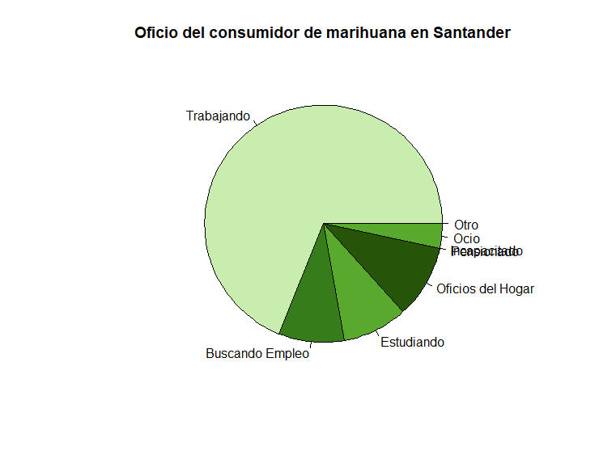

**3. Consumo y educación:**

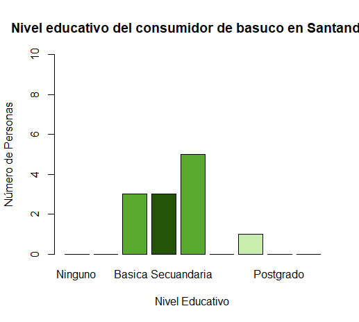

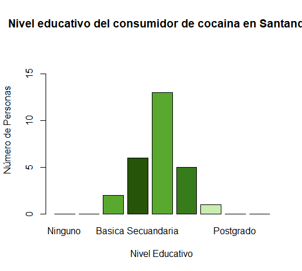

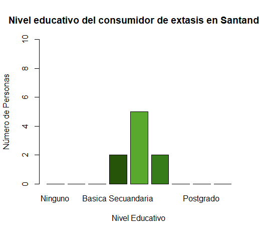

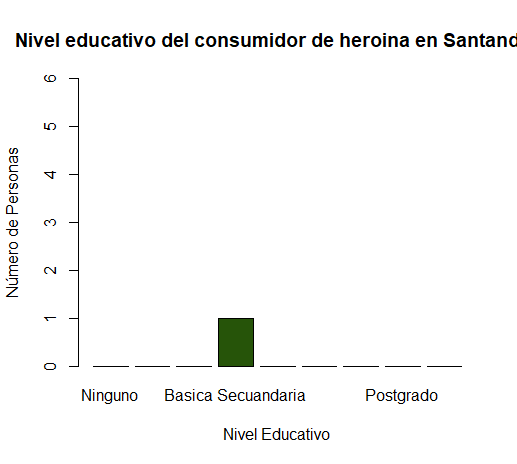

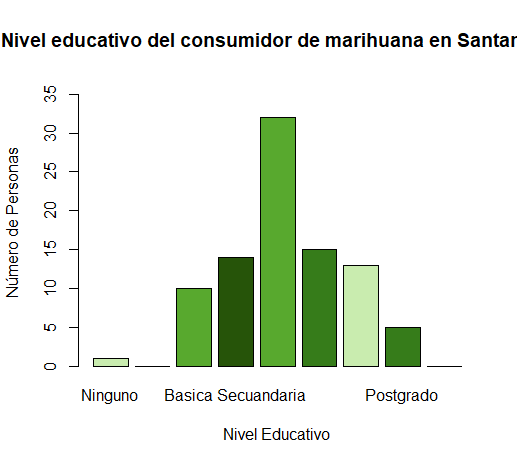

**4. Consumo y por género:**

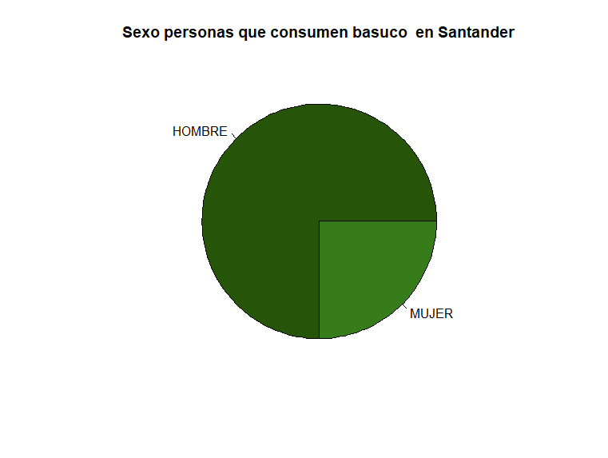

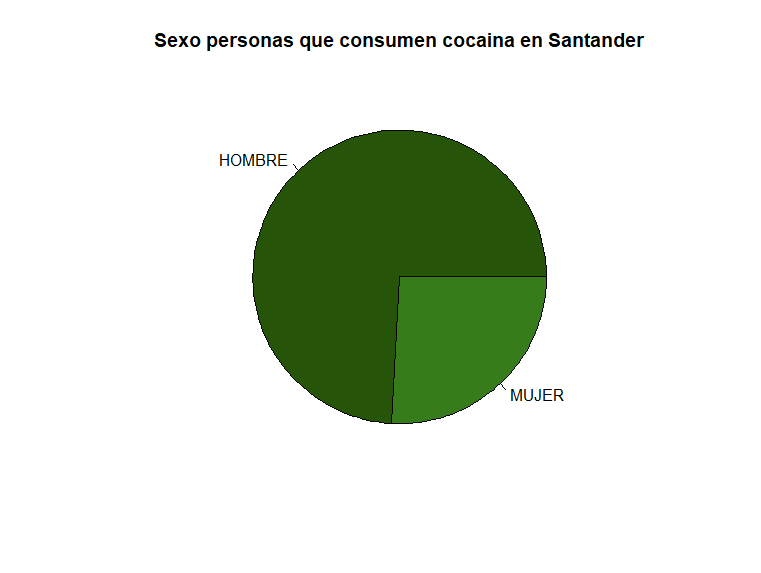

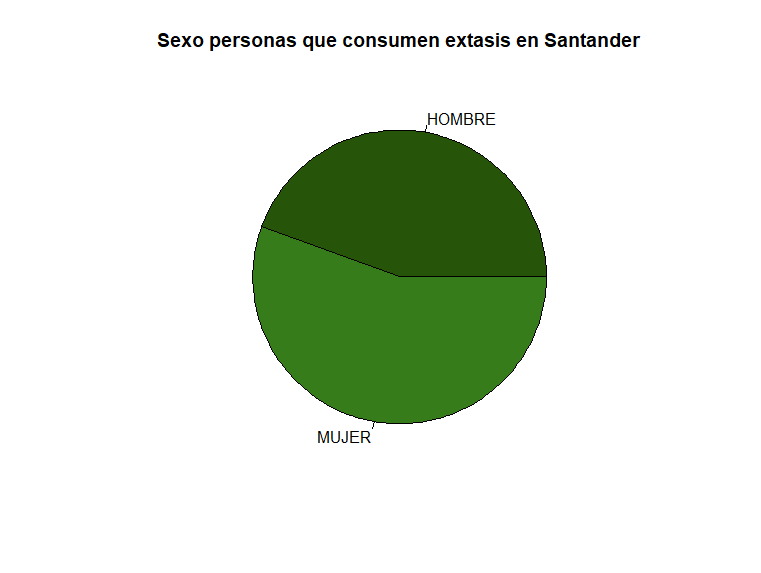

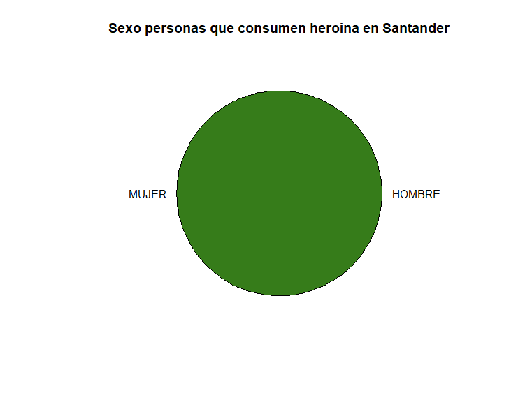

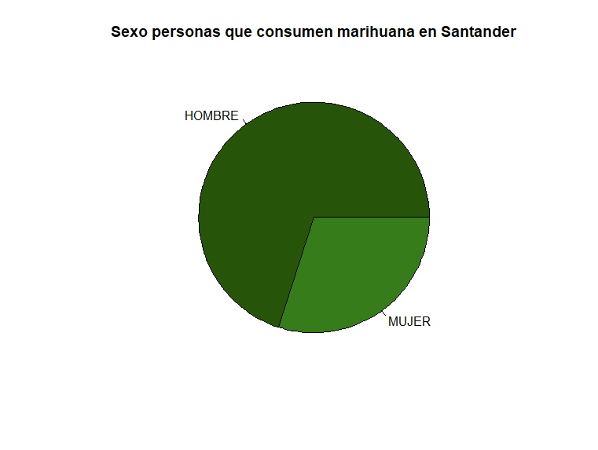

**5. Consumo y raices culturales:**

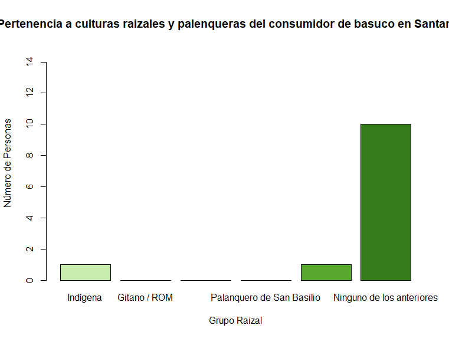

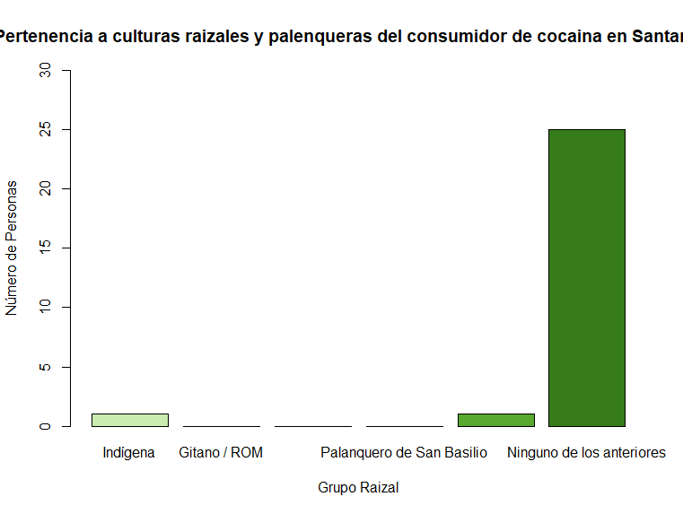